# small-RNA analysis

The most recent update of this html document occurred: Fri Sep 30 17:00:20 2016

```r
> knitr::opts_chunk$set(tidy=TRUE, highlight=TRUE, dev="png", fig.width=6,fig.heigh=6,
+                cache=TRUE, highlight=TRUE, autodep=TRUE,
+                warning=FALSE, error=FALSE,
+                message=FALSE, prompt=TRUE, comment='', fig.cap='', bootstrap.show.code=FALSE)
```

```r
> library(knitr)
> library(ggplot2)
> library(reshape)
> library(DESeq2)
> library(genefilter)
> library(CHBUtils)
> library(gtools)
> library(gridExtra)
> library(devtools)
> library(dplyr)
> library(isomiRs)
> library(pheatmap)
> library(myRfunctions)
>
> root_path = "~/orch/scratch/charest_egfr_srna/egfr_srna/work/upload"
> root_file = file.path(root_path, "srna_out_files")
> dir.create(root_file, showWarnings = FALSE)
>
> metadata_fn = list.files(file.path(root_path), pattern = "summary.csv", recursive = T,
+     full.names = T)
> metadata = read.csv(metadata_fn[2], row.names = "sample_id")
> # metadata = metadata[2:nrow(metadata), ,drop=FALSE]
> condition = names(metadata)[1]
> design = metadata
> formula = ~condition  # modify this to get your own formula
```

# Introduction

> We are interested in the role of EGFR signaling in determining the differential export of RNA into extracellular vesicles. To test this we took a mouse-derived glioblastoma cell line and treated them with the EGFR inhibitor gefitinib or vehicle alone (DMSO). From these cells, we took conditioned media, centrifuged to pellet out any cells and ran this cleared supernatant through a series of filters with increasingly smaller pore sizes. The pore sizes were chosen to capture extracellular vesicles of different categories (2 µm = cellular debris, 0.8 µm = oncosomes, 0.22 µm = microvesicles, 0.02 µm = exosomes and 3 kDa = RNPs). We then lysed the vesicles on the 0.22, 0.02 and 3kDa filters, prepared total RNA from these fractions and the parental cells and sent this RNA for sequencing at BGI.

# Exploratory analysis

In this section we will see descriptive figures about quality of the data, reads with adapter, reads mapped to miRNAs, reads mapped to other small RNAs.

## size distribution

After adapter removal, we can plot the size distribution of the small RNAs.

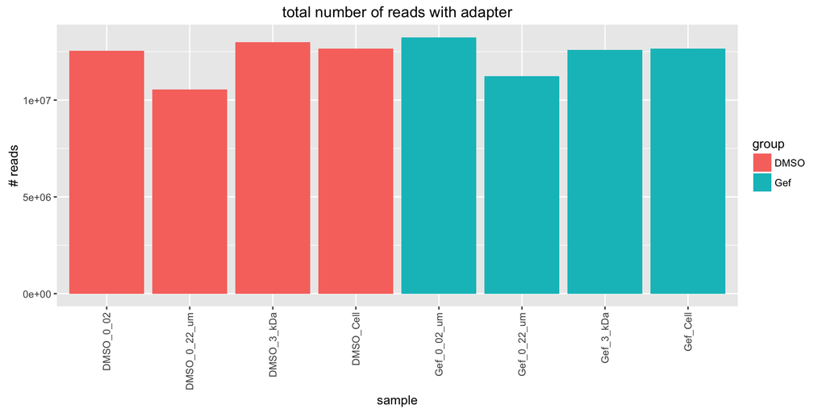

```r
> files = list.files(file.path(root_path), pattern = "trimming_stats", recursive = T)
>
> names(files) = sapply(files, function(x) {
+     gsub("-ready.trimming_stats", "", basename(x))
+ })
>
>
> tab = data.frame()
> for (sample in rownames(metadata)) {
+     d = read.table(file.path(root_path, files[sample]), sep = " ")
+     tab = rbind(tab, d %>% mutate(sample = sample, group = metadata[sample,
+         condition]))
+ }
>
>
> reads_adapter = tab %>% group_by(sample, group) %>% summarise(total = sum(V2))
> ggplot(reads_adapter, aes(x = sample, y = total, fill = group)) + geom_bar(stat = "identity",
+     position = "dodge") + ggtitle("total number of reads with adapter") + ylab("# reads") +
+     theme(axis.text.x = element_text(angle = 90, vjust = 0.5, hjust = 1))
```

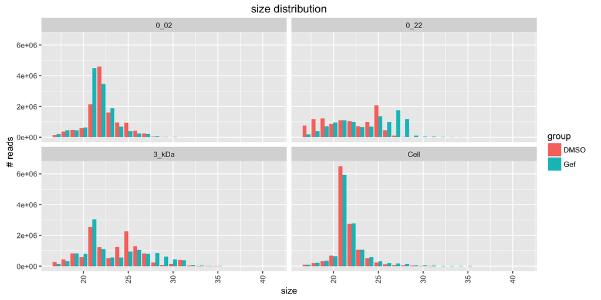

```r
> tab$selection = gsub("_um", "", gsub("^[[:alpha:]]+_", "", tab$sample))
> ggplot(tab, aes(x = V1, y = V2, fill = group, group = sample)) + geom_bar(stat = "identity",
+     position = "dodge") + facet_wrap(~selection, ncol = 2) + ggtitle("size distribution") +
+     ylab("# reads") + xlab("size") + theme(axis.text.x = element_text(angle = 90,
+     vjust = 0.5, hjust = 1))
```

## Spike-in sequences

Reads were normalized using total number of reads with adapters. (RPM)

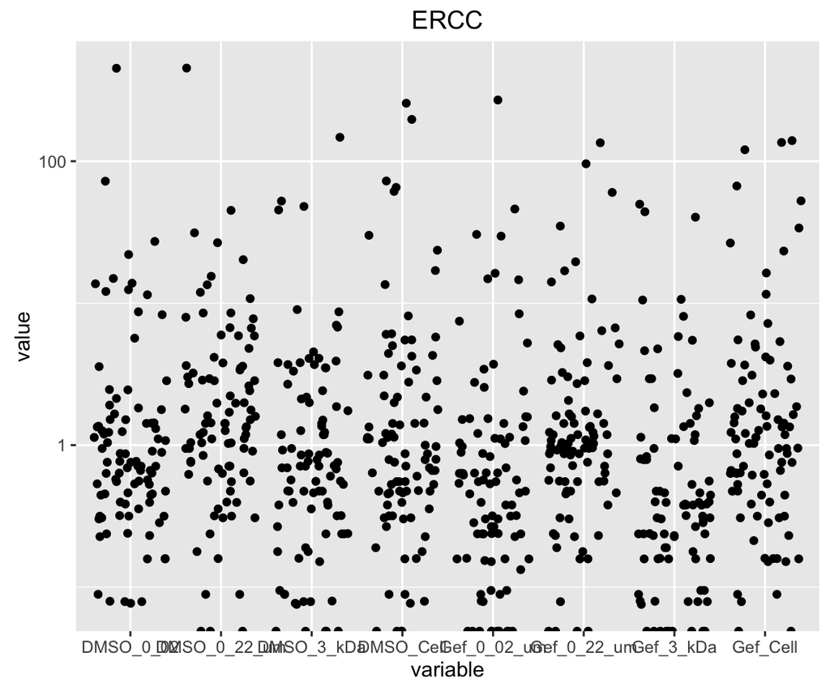

```r
> library(readr)
> spike = read_delim(file.path(root_path, "..", "spikein", "combined.sf"), delim = "\t")
> spike = spike %>% dplyr::select(name, numreads, sample) %>% tidyr::spread(key = "sample",
+     value = "numreads")
>
> spike_norm = sweep(spike[, 2:ncol(spike)], 1, reads_adapter$total, "/") * 1e+06
> row.names(spike_norm) = spike$name
>
> ercc = melt(spike_norm %>% as.data.frame() %>% row2colnames("id")) %>% filter(grepl("ERCC",
+     id))
> uni = melt(spike_norm %>% as.data.frame() %>% row2colnames("id")) %>% filter(!grepl("ERCC",
+     id))
>
> ggplot(ercc, aes(x = variable, y = value)) + geom_jitter() + scale_y_log10() +
+     ggtitle("ERCC")
```

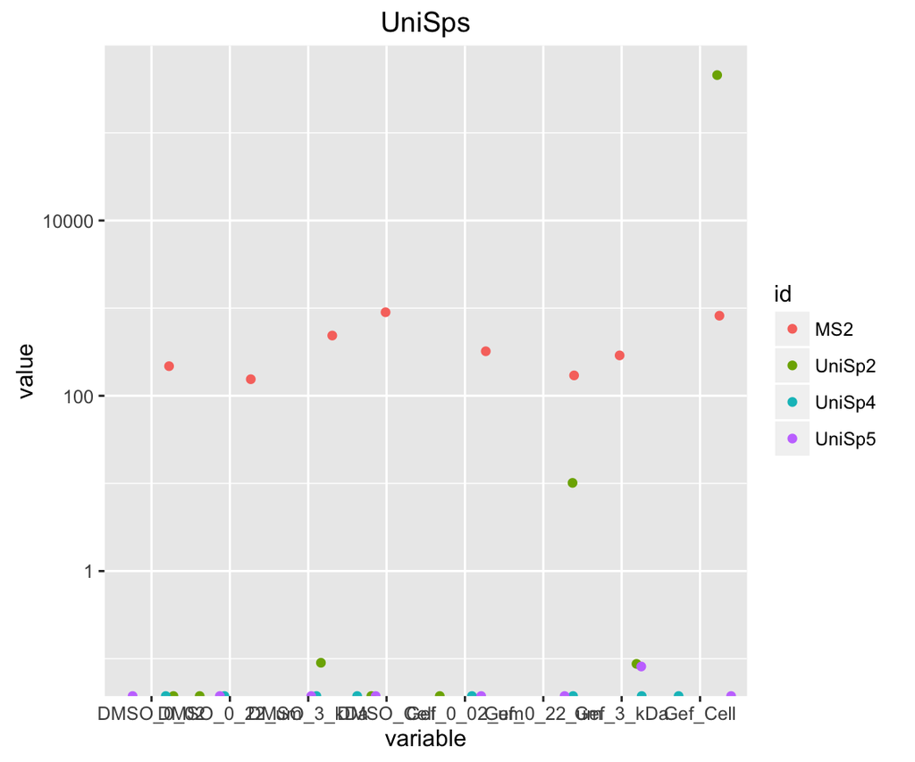

```r
> ggplot(uni, aes(x = variable, y = value, color = id)) + geom_jitter() + scale_y_log10() +
+     ggtitle("UniSps")
```

```r
> files = list.files(file.path(root_path), pattern = "mirbase-ready", recursive = T,
+     full.names = T)
> ismirbase = length(files) > 0
> mirdeep2_files = list.files(file.path(root_path), pattern = "novel-ready", recursive = T,
+     full.names = T)
> ismirdeep2 = length(mirdeep2_files) > 0
```

## miRNA

### total miRNA expression annotated with mirbase

```r
> names(files) = sapply(files, function(x) {
+     gsub("-mirbase-ready.counts", "", basename(x))
+ })
>
> obj <- IsomirDataSeqFromFiles(files = files[rownames(design)], design = design,
+     header = T, skip = 0)
```

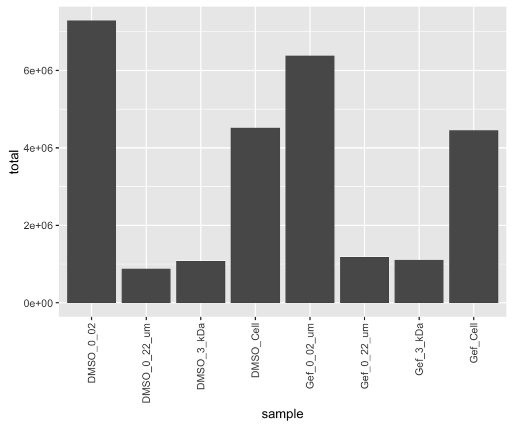

```r
> ggplot(data.frame(sample = colnames(counts(obj)), total = colSums(counts(obj)))) +
+     geom_bar(aes(x = sample, y = total), stat = "identity") + theme(axis.text.x = element_text(angle = 90,
+     vjust = 0.5, hjust = 1))
```

```r
> mirna_step <- as.data.frame(colSums(counts(obj)))
```

### Distribution of mirna expression

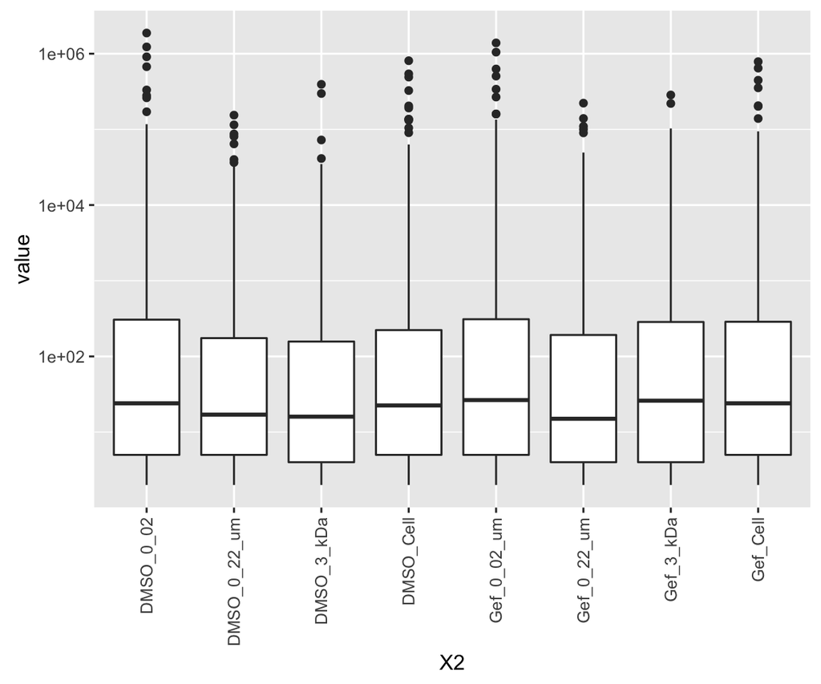

```r
> ggplot(melt(counts(obj))) + geom_boxplot(aes(x = X2, y = value)) + scale_y_log10() +
+     theme(axis.text.x = element_text(angle = 90, vjust = 0.5, hjust = 1))
```

### cumulative distribution of miRNAs

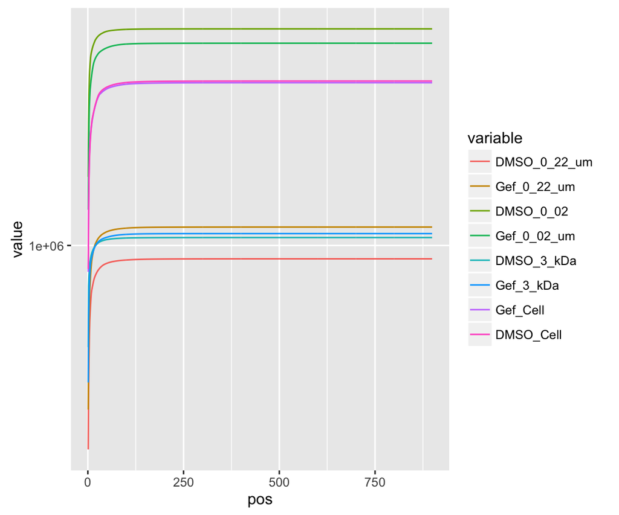

```r
> cs <- as.data.frame(apply(counts(obj), 2, function(x) {
+     cumsum(sort(x, decreasing = T))
+ }))
> cs$pos <- 1:nrow(cs)
>
> ggplot((melt(cs, id.vars = "pos"))) + geom_line(aes(x = pos, y = value, color = variable)) +
+     scale_y_log10()
```

### Clustering

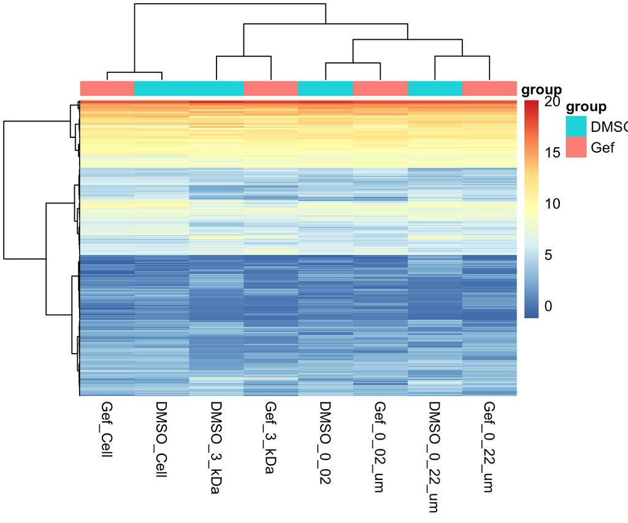

```r
> counts = counts(obj)
> dds = DESeqDataSetFromMatrix(counts[rowSums(counts > 0) > 3, ], colData = design,
+     design = ~1)
> vst = rlog(dds)
>
> pheatmap(assay(vst), annotation_col = design[, 1, drop = F], show_rownames = F,
+     clustering_distance_cols = "correlation", clustering_method = "ward.D")
```

### MDS plot

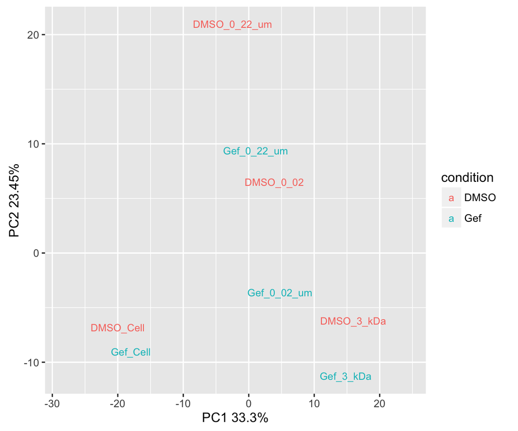

```r
> mds(assay(vst), condition = design[, condition])
```

### complexity

```r
> kable(as.data.frame(colSums(counts > 10)))
```

|  | colSums(counts > 10) |
| --- | --- |
| DMSO_0_22_um | 246 |
| Gef_0_22_um | 248 |
| DMSO_0_02 | 346 |
| Gef_0_02_um | 364 |
| DMSO_3_kDa | 205 |
| Gef_3_kDa | 233 |
| Gef_Cell | 410 |
| DMSO_Cell | 425 |

## Others small RNA

The data was analyzed with [seqcluster](http://seqcluster.readthedocs.org/)

This tools used all reads, uniquely mapped and multi-mapped reads. The first step is to cluster sequences in all locations they overlap. The second step is to create meta-clusters: is the unit that merge all clusters that share the same sequences. This way the output are meta-clusters, common sequences that could come from different region of the genome.

### genome covered

```r
> fn_json = list.files(file.path(root_path), pattern = "seqcluster.json", recursive = T,
+     full.names = T)
> seq_dir = dirname(fn_json[2])
>
> # cov_stats <- read.table(file.path(root_path, '..', 'align',
> # 'seqs_rmlw.bam_cov.tsv'),sep='\t',check.names = F)
>
> # kable(cov_stats[cov_stats$V1=='genome',] %>%
> # dplyr::select(coverage=V2,ratio_genome=V5), row.names = FALSE)
```

The normal value for human data with strong small RNA signal is: 0.0002. This will change for smaller genomes.

### classification

Number of reads in the data after each step:

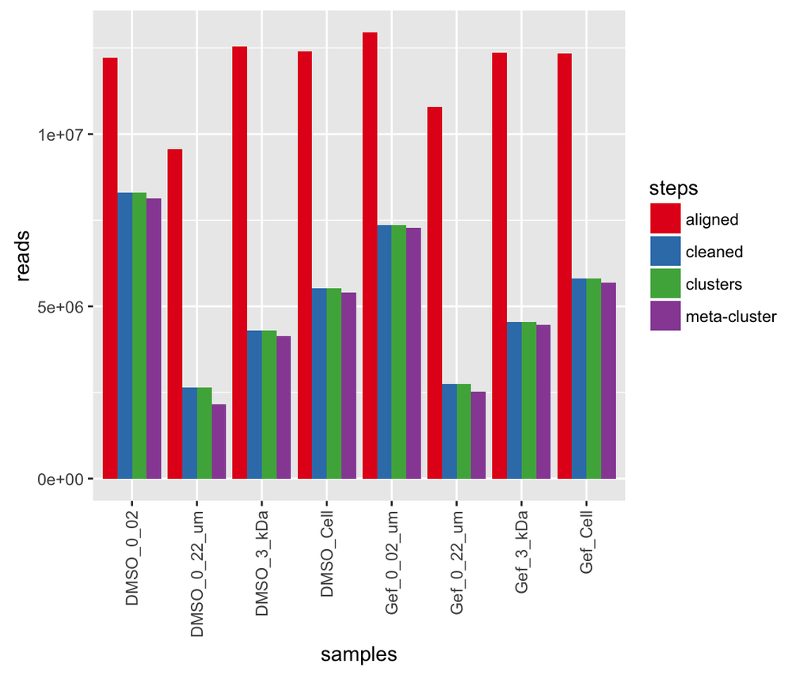

```r
> reads_stats <- read.table(file.path(seq_dir, "read_stats.tsv"), sep = "\t",
+     check.names = F)
> ggplot(reads_stats, aes(x = V2, y = V1, fill = V3)) + geom_bar(stat = "identity",
+     position = "dodge") + labs(list(x = "samples", y = "reads")) + scale_fill_brewer("steps",
+     palette = "Set1") + theme(axis.text.x = element_text(angle = 90, vjust = 0.5,
+     hjust = 1))
```

```r
> clus <- read.table(file.path(seq_dir, "counts.tsv"), header = T, sep = "\t",
+     row.names = 1, check.names = FALSE)
> ann <- clus[, 2]
> toomany <- clus[, 1]
> clus_ma <- clus[, 3:ncol(clus)]
> clus_ma = clus_ma[, row.names(design)]
```

Check complex meta-clusters: This kind of events happen when there are small RNA over the whole genome, and all repetitive small rnas map to thousands of places and sharing many sequences in many positions. If any meta-cluster is > 40% of the total data, maybe it is worth to add some filters like: minimum number of counts `-e` or `--min--shared` in `seqcluster prepare`

```r
> library(edgeR)
> clus_ma_norm = cpm(DGEList(clus_ma), normalized.lib.sizes = TRUE)
> head(clus_ma_norm[toomany > 0, ])
```

```
     DMSO_0_22_um Gef_0_22_um DMSO_0_02 Gef_0_02_um DMSO_3_kDa Gef_3_kDa
     Gef_Cell DMSO_Cell
```

### Clustering

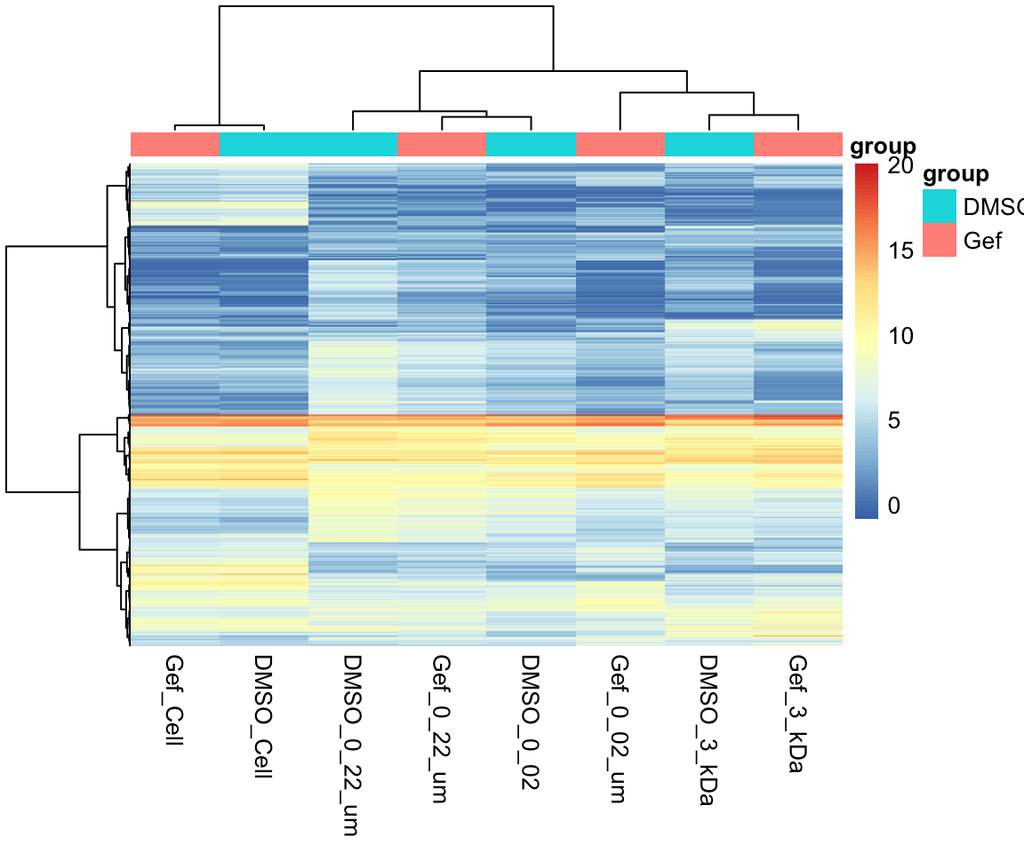

```r
> counts_c = clus_ma
> dds_c = DESeqDataSetFromMatrix(counts_c[rowSums(counts_c > 0) > 3, ], colData = design,
+     design = ~1)
> vst_c = rlog(dds_c)
>
> pheatmap(assay(vst_c), annotation_col = design[, 1, drop = F], show_rownames = F,
+     clustering_distance_cols = "correlation", clustering_method = "ward.D")
```

### MDS plot

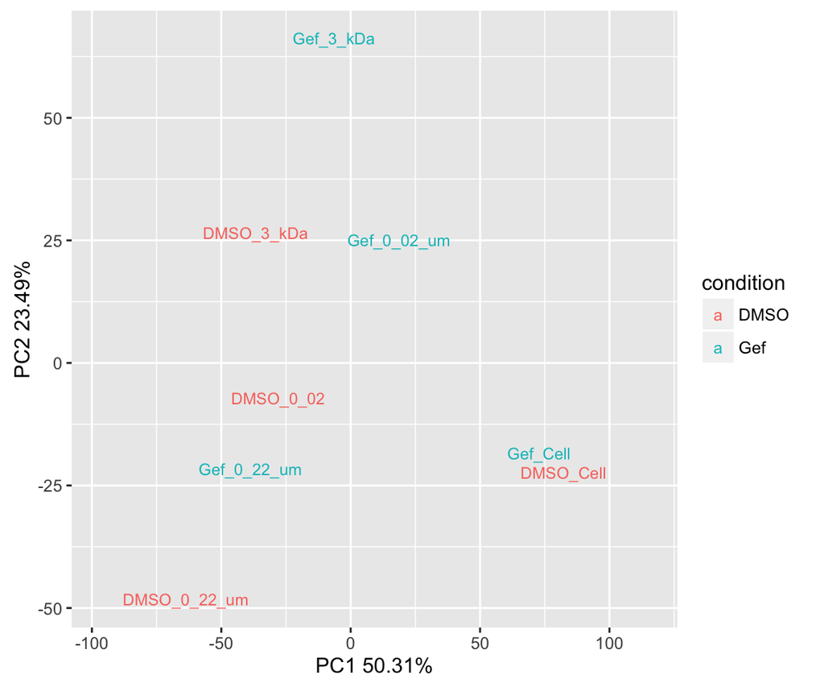

```r
> mds(assay(vst_c), condition = design[, condition])
```

### complexity

```r
> kable(as.data.frame(colSums(clus_ma > 10)))
```

|  | colSums(clus_ma > 10) |
| --- | --- |
| DMSO_0_22_um | 1414 |
| Gef_0_22_um | 1417 |
| DMSO_0_02 | 1231 |
| Gef_0_02_um | 990 |
| DMSO_3_kDa | 1255 |
| Gef_3_kDa | 911 |
| Gef_Cell | 1252 |
| DMSO_Cell | 1133 |

### Contribution by class

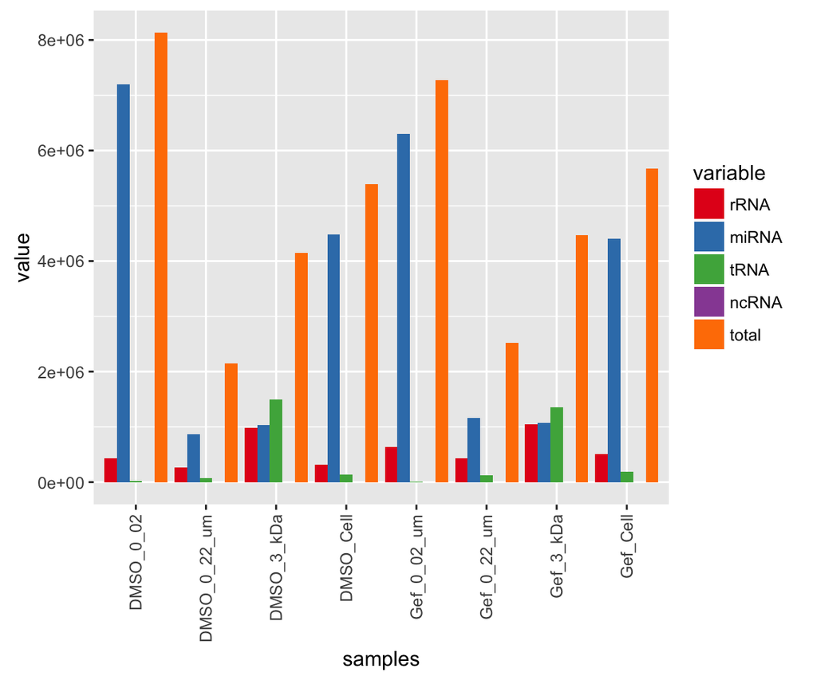

```r
> rRNA <- colSums(clus_ma[grepl("rRNA", ann) & grepl("miRNA", ann) == F, ])
> miRNA <- colSums(clus_ma[grepl("miRNA", ann), ])
> tRNA <- colSums(clus_ma[grepl("tRNA", ann) & grepl("rRNA", ann) == F & grepl("ncRNA",
+     ann) == F & grepl("miRNA", ann) == F, ])
> rmsk <- colSums(clus_ma[grepl("ncRNA", ann) & grepl("rRNA", ann) == F & grepl("miRNA",
+     ann) == F, ])
> total <- colSums(clus_ma)
>
> dd <- data.frame(samples = names(rRNA), rRNA = rRNA, miRNA = miRNA, tRNA = tRNA,
+     ncRNA = rmsk, total = total)
> ggplot(melt(dd)) + geom_bar(aes(x = samples, y = value, fill = variable), stat = "identity",
+     position = "dodge") + scale_fill_brewer(palette = "Set1") + theme(axis.text.x = element_text(angle = 90,
+     vjust = 0.5, hjust = 1))
```

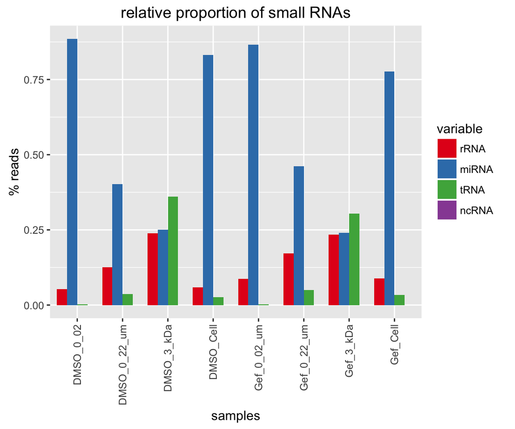

```r
> dd_norm = dd
> dd_norm[, 2:5] = sweep(dd[, 2:5], 1, dd[, 6], "/")
> ggplot(melt(dd_norm[, 1:5])) + geom_bar(aes(x = samples, y = value, fill = variable),
+     stat = "identity", position = "dodge") + scale_fill_brewer(palette = "Set1") +
+     theme(axis.text.x = element_text(angle = 90, vjust = 0.5, hjust = 1)) +
+     labs(list(title = "relative proportion of small RNAs", y = "% reads"))
```

```r
> # size_clus <- read.table(file.path(root_path, '..', 'seqcluster',
> # 'cluster', 'size_counts.tsv'),sep='\t',check.names = F)
```

# Differential expression

```r
> ma_rank = do.call(cbind, lapply(colnames(counts), function(col) {
+     idx = sort(counts[, col], decreasing = T, index.return = T)
+     r <- 1:length(idx$ix)
+     r[order(idx$ix)]
+ }))
> row.names(ma_rank) = row.names(counts)
> colnames(ma_rank) = colnames(counts)
>
> save_file(counts, "mirna_counts.csv", root_file)
> save_file(ma_rank, "mirna_rank_counts.csv", root_file)
```

```r
> mac_rank = do.call(cbind, lapply(colnames(clus_ma), function(col) {
+     idx = sort(clus_ma[, col], decreasing = T, index.return = T)
+     r <- 1:length(idx$ix)
+     r[order(idx$ix)]
+ }))
> row.names(mac_rank) = row.names(clus_ma)
> colnames(mac_rank) = colnames(clus_ma)
> save_file(clus_ma, "clus_counts.csv", root_file)
> save_file(mac_rank, "clus_rank_counts.csv", root_file)
```

# Files

# R Session Info

(useful if replicating these results)